# Probability

Statistical Inference

Brian Caffo, Jeff Leek, Roger Peng

## Notation

- The **sample space**, $\Omega$, is the collection of possible outcomes of an experiment
- Example: die roll $\Omega = \{1,2,3,4,5,6\}$
- An **event**, say $E$, is a subset of $\Omega$
- Example: die roll is even $E = \{2,4,6\}$
- An **elementary** or **simple** event is a particular result of an experiment
- Example: die roll is a four, $\omega = 4$
- $\emptyset$ is called the **null event** or the **empty set**

## Interpretation of set operations

Normal set operations have particular interpretations in this setting

1. $\omega \in E$ implies that $E$ occurs when $\omega$ occurs
2. $\omega \not\in E$ implies that $E$ does not occur when $\omega$ occurs
3. $E \subset F$ implies that the occurrence of $E$ implies the occurrence of $F$
4. $E \cap F$ implies the event that both $E$ and $F$ occur
5. $E \cup F$ implies the event that at least one of $E$ or $F$ occur
6. $E \cap F=\emptyset$ means that $E$ and $F$ are **mutually exclusive**, or cannot both occur
7. $E^c$ or $\bar E$ is the event that $E$ does not occur

## Probability

A **probability measure**, $P$, is a function from the collection of possible events so that the following hold

1. For an event $E\subset \Omega$, $0 \leq P(E) \leq 1$
2. $P(\Omega) = 1$
3. If $E_1$ and $E_2$ are mutually exclusive events $P(E_1 \cup E_2) = P(E_1) + P(E_2)$.

Part 3 of the definition implies **finite additivity**

$$P(\cup_{i=1}^n A_i) = \sum_{i=1}^n P(A_i)$$
where the $\{A_i\}$ are mutually exclusive. (Note a more general version of additivity is used in advanced classes.)

## Example consequences

- $P(\emptyset) = 0$
- $P(E) = 1 - P(E^c)$
- $P(A \cup B) = P(A) + P(B) - P(A \cap B)$
- if $A \subset B$ then $P(A) \leq P(B)$
- $P\left(A \cup B\right) = 1 - P(A^c \cap B^c)$
- $P(A \cap B^c) = P(A) - P(A \cap B)$
- $P(\cup_{i=1}^n E_i) \leq \sum_{i=1}^n P(E_i)$
- $P(\cup_{i=1}^n E_i) \geq \max_i P(E_i)$

## Example

The National Sleep Foundation ([www.sleepfoundation.org](http://www.sleepfoundation.org/)) reports that around 3% of the American population has sleep apnea. They also report that around 10% of the North American and European population has restless leg syndrome. Does this imply that 13% of people will have at least one sleep problems of these sorts?

## Example continued

Answer: No, the events are not mutually exclusive. To elaborate let:

$$\begin{eqnarray*}
A_1 & = & \{\mbox{Person has sleep apnea}\} \\
A_2 & = & \{\mbox{Person has RLS}\}
\end{eqnarray*}$$

Then

$$\begin{eqnarray*}
P(A_1 \cup A_2 ) & = & P(A_1) + P(A_2) - P(A_1 \cap A_2) \\
& = & 0.13 - \mbox{Probability of having both}
\end{eqnarray*}$$
Likely, some fraction of the population has both.

## Random variables

- A **random variable** is a numerical outcome of an experiment.
- The random variables that we study will come in two varieties, **discrete** or **continuous**.
- Discrete random variable are random variables that take on only a countable number of possibilities.
- $P(X = k)$
- Continuous random variable can take any value on the real line or some subset of the real line.
- $P(X \in A)$

## Examples of variables that can be thought of as random variables

- The $(0-1)$ outcome of the flip of a coin
- The outcome from the roll of a die
- The BMI of a subject four years after a baseline measurement
- The hypertension status of a subject randomly drawn from a population

## PMF

A probability mass function evaluated at a value corresponds to the probability that a random variable takes that value. To be a valid pmf a function, $p$, must satisfy

1. $p(x) \geq 0$ for all $x$
2. $\sum_{x} p(x) = 1$

The sum is taken over all of the possible values for $x$.

## Example

Let $X$ be the result of a coin flip where $X=0$ represents tails and $X = 1$ represents heads.
$$p(x) = (1/2)^{x} (1/2)^{1-x} ~~\mbox{ for }~~x = 0,1$$
Suppose that we do not know whether or not the coin is fair; Let $\theta$ be the probability of a head expressed as a proportion (between 0 and 1).
$$p(x) = \theta^{x} (1 - \theta)^{1-x} ~~\mbox{ for }~~x = 0,1$$

## PDF

A probability density function (pdf), is a function associated with a continuous random variable

*Areas under pdfs correspond to probabilities for that random variable*

To be a valid pdf, a function $f$ must satisfy

1. $f(x) \geq 0$ for all $x$
2. The area under $f(x)$ is one.

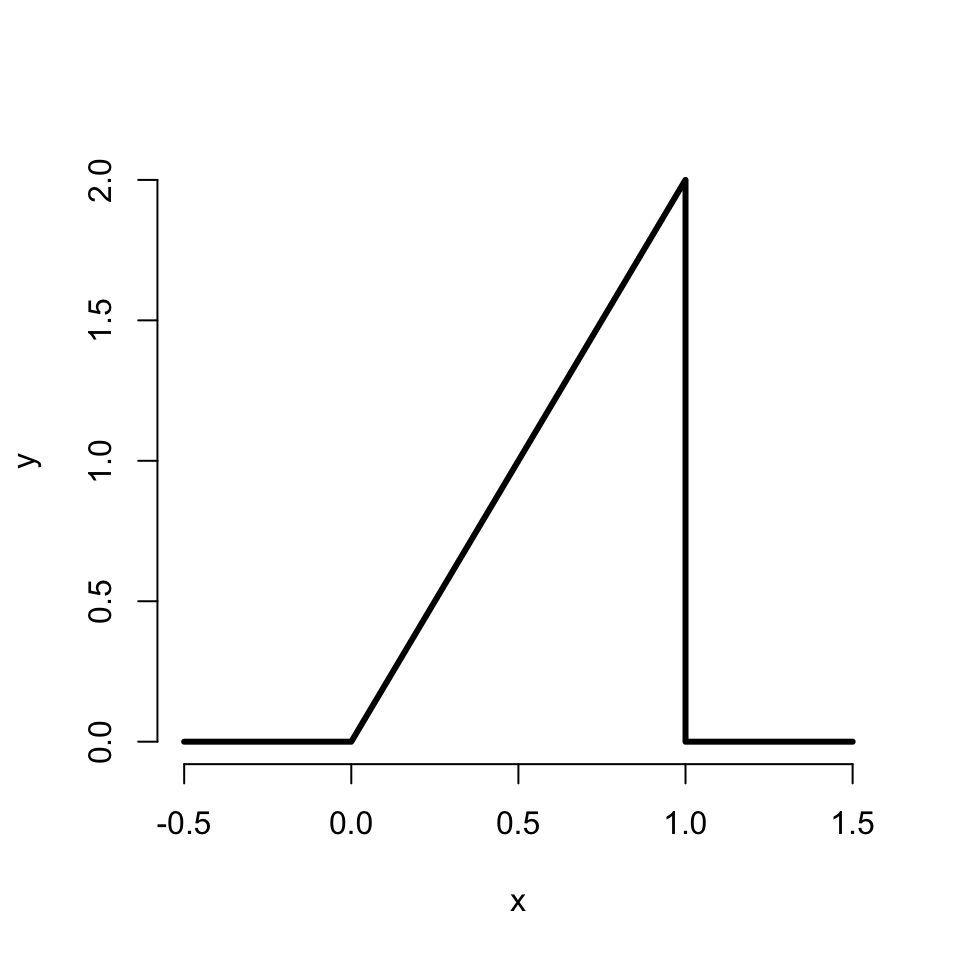

```r
x <- c(-0.5, 0, 1, 1, 1.5); y <- c( 0, 0, 2, 0, 0)
plot(x, y, lwd = 3, frame = FALSE, type = "l")
```

## Example continued

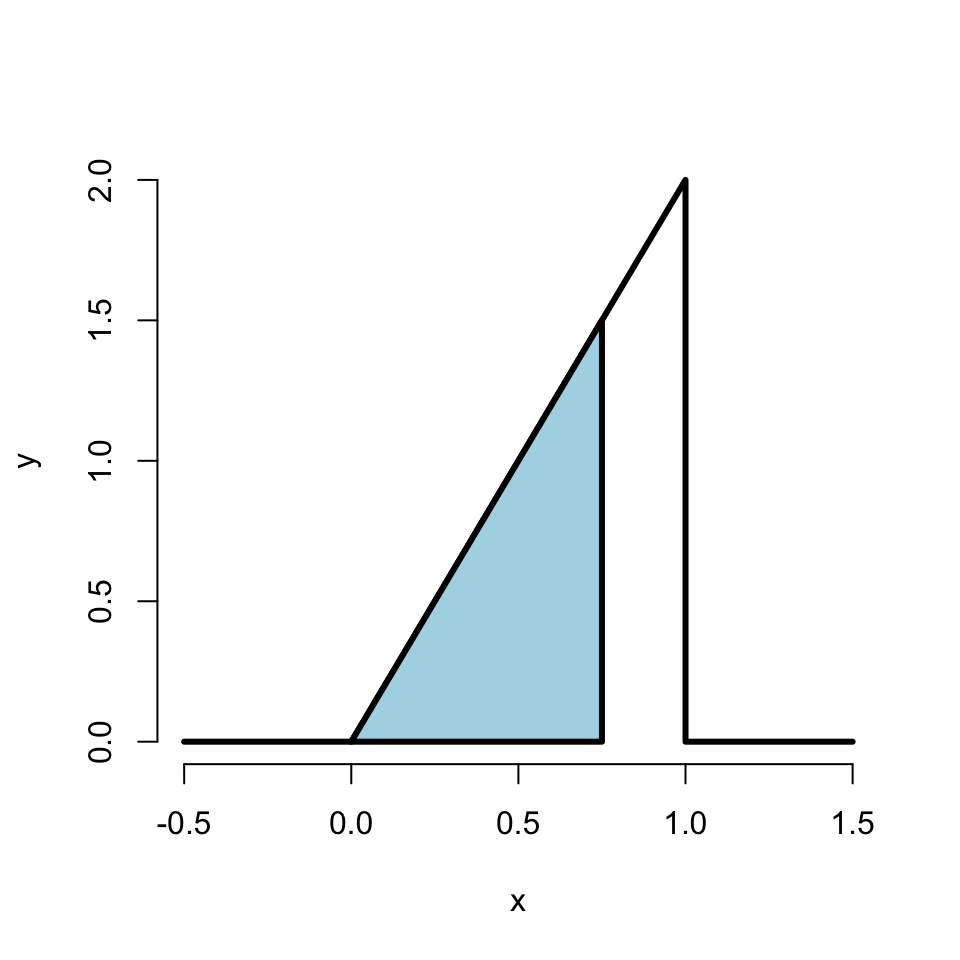

```r
1.5 * .75 / 2
```

```
## [1] 0.5625
```

```r
pbeta(.75, 2, 1)
```

```
## [1] 0.5625
```

## CDF and survival function

- The **cumulative distribution function** (CDF) of a random variable $X$ is defined as the function
  $$F(x) = P(X \leq x)$$
- This definition applies regardless of whether $X$ is discrete or continuous.
- The **survival function** of a random variable $X$ is defined as
  $$S(x) = P(X > x)$$
- Notice that $S(x) = 1 - F(x)$
- For continuous random variables, the PDF is the derivative of the CDF

## Example

What are the survival function and CDF from the density considered before?

For $1 \geq x \geq 0$
$$F(x) = P(X \leq x) = \frac{1}{2} Base \times Height = \frac{1}{2} (x) \times (2 x) = x^2$$

$$S(x) = 1 - x^2$$

```r
pbeta(c(0.4, 0.5, 0.6), 2, 1)
```

```
## [1] 0.16 0.25 0.36
```

## Quantiles

- The $\alpha^{th}$ **quantile** of a distribution with distribution function $F$ is the point $x_\alpha$ so that
  $$F(x_\alpha) = \alpha$$
- A **percentile** is simply a quantile with $\alpha$ expressed as a percent
- The **median** is the $50^{th}$ percentile

## Summary

- You might be wondering at this point “I’ve heard of a median before, it didn’t require integration. Where’s the data?”
- We’re referring to are **population quantities**. Therefore, the median being discussed is the **population median**.
- A probability model connects the data to the population using assumptions.
- Therefore the median we’re discussing is the **estimand**, the sample median will be the **estimator**